# Estudios de Informática, Multimedia y Telecomunicaciones

# PAC2_Estadística_CARLOS_TORO_PEÑAS

Carlos Toro Peñas

2022-11-08

# 1 Lectura del archivo

```
## 'data.frame':    235158 obs. of  43 variables:
##  $ X.1     : int  1 2 3 4 5 6 7 8 9 10 ...
##  $ X       : int  1 2 3 4 5 6 7 8 9 10 ...
##  $ SEQNUM  : int  1 2 3 4 5 6 7 8 9 10 ...
##  $ OSEQNUM : int  2 1 1 1 1 1 1 1 1 1 ...
##  $ NAME    : chr  "TGS436Z001" "TGS496Z001" "TGS435Z001" "TGS436Z002" ...
##  $ UKST    : int  349 349 349 349 349 349 349 349 349 349 ...
##  $ RA1950.h: int  0 0 0 0 0 0 0 0 0 0 ...
##  $ RA1950.m: int  11 11 11 11 11 11 11 11 11 11 ...
##  $ RA1950.s: num  55.7 59.3 49.4 53.1 54.6 ...
##  $ DE1950.d: int  -32 -33 -32 -32 -32 -33 -33 -33 -33 -32 ...
##  $ DE1950.m: int  32 14 39 46 59 8 17 19 23 32 ...
##  $ DE1950.s: num  55.2 41.3 57.4 28.2 22.1 25.4 28.4 20.2 31.9 45.4 ...
##  $ RAh     : int  0 0 0 0 0 0 0 0 0 0 ...
##  $ Ram     : int  14 14 14 14 14 14 14 14 14 14 ...
```

[output cut: 29 more lines]

# 2 Preprocesado de datos

### 2.0.1 Análisis descriptivo.

#### 2.0.1.1 **Seleccion de datos y visualización**

Take a sample with:

$$RA \in [0, 1],\, DEC \in [-29, -27],\,
\,and\,\, z \lt max\_redshift$$

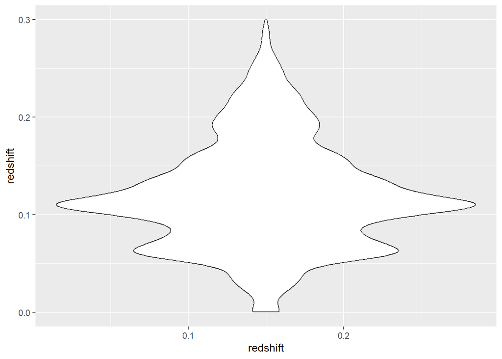

```r
min_members <- 5
max_redshift <- 0.3
# Take a sample
dt_sample3 <- dt[dt$Q_Z>3 & dt$RAh<=1 & dt$RAh>=0 & dt$Ded>=-29 & dt$Ded<=-27,]
dt_sample3 <- dt_sample3[dt_sample3$Z< max_redshift,]
#Change column name
names(dt_sample3)[names(dt_sample3) == 'Z'] <- 'redshift'

#Take the parameters necessary for clustering effect.
dt_sample3<- dt_sample3[,c('SEQNUM','x', 'y', 'z', 'redshift',  "dist")]

# mm is an object containing both groups and galaxy identification
mm<-merge(dt_sample3, dt_groups, by.x = 'SEQNUM', by.y = 'ID_2DF')
ggplot(dt_sample3, aes(x=redshift, y=redshift))+geom_violin()
```

DBOptics clustering:

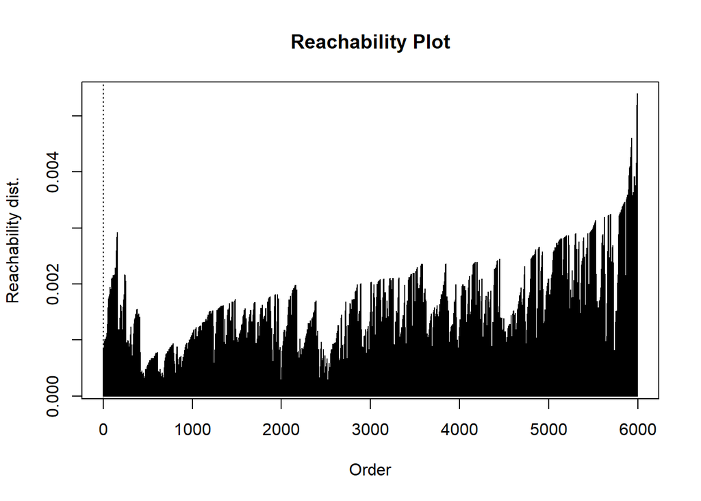

```r
points<- mm[,c('x', 'y', 'z')]

#clustering
res <- optics(points, minPts = min_members)
plot(res)
```

DBSCAN application:

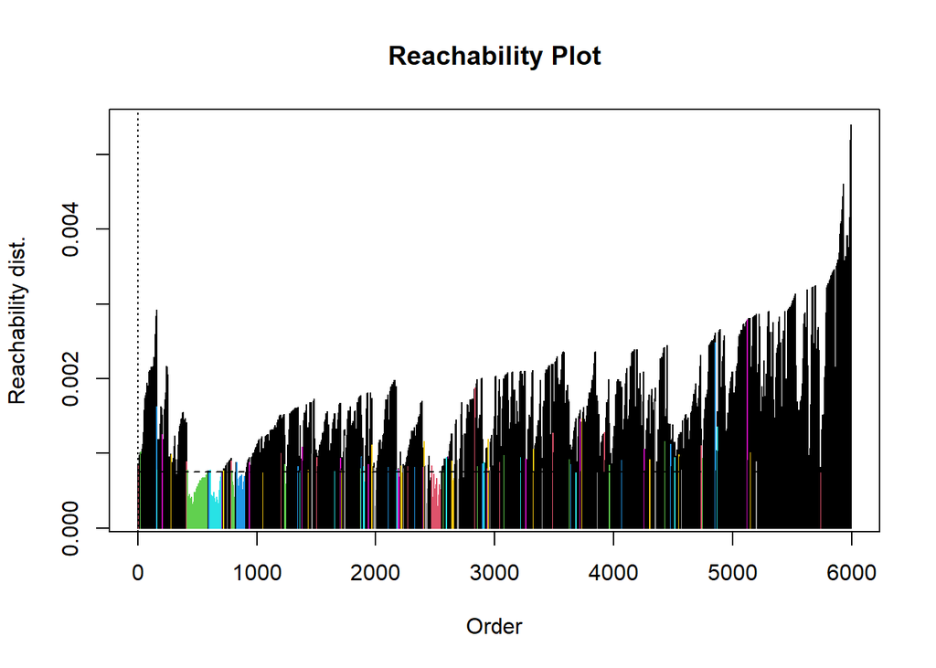

```r
blo_scan <- extractDBSCAN(res, eps_cl = 0.00075)
plot(blo_scan)
```

Select groups with more than min_members members

```r
h<-sqldf("SELECT count(SEQNUM) as members, GROUP_ID FROM mm GROUP BY GROUP_ID order by members DESC")
h2<-sqldf(sprintf("SELECT mm.x, mm.y, mm.z, mm.GROUP_ID FROM mm as mm, h
    where mm.GROUP_ID=h.GROUP_ID and h.members >= %s", min_members))

true_groups <- length(unique(h2$GROUP_ID))
mm$cluster_id <- blo_scan$cluster
print(sprintf('Number of galaxies in groups with more than %s elements %s out of %s', min_members , dim(h2)[1], dim(mm)[1]))
```

```
## [1] "Number of galaxies in groups with more than 5 elements 774 out of 5995"
```

We have, on one hand all groups with more than min_members members (made up by a reduced amount of galaxies from catalog):

```r
plot3d(h2$x, h2$y, h2$z, col = h2$GROUP_ID,
       size = 2, xlab = "X", ylab = "Y", zlab = "Z")
```

in the other hand the output-clusters from DBSCAN:

```r
plot3d(points$x, points$y, points$z,
       col = blo_scan$cluster + 1, size = 2,
       xlab = "X", ylab = "Y", zlab = "Z")
```

Following code is devoted to asses the outcomes obtained with from an given output-cluster:

```r
###############################################################################
#   Number of elements in a given output-cluster
###############################################################################
calculate_count_of_cluster <- function(cluster_id, dataset){
    ttotal<-sqldf(sprintf("select count(seqnum) as how_many
            from dataset
                where cluster =%s", cluster_id))
}


###############################################################################
#   Number of elements in a given true-group
###############################################################################
calculate_count_of_group <- function(group_id, dataset){
    ttotal<-sqldf(sprintf("select count(seqnum) as how_many
        from dataset
            where group_id=%s
            group by group_id", group_id))
    list('how_many' = ttotal$how_many)
}


###############################################################################
#   The most common group of a given cluster and count elements in the
#   intersection group and cluster.
###############################################################################
calculate_majority_group <- function(cluster_id, dataset){
    ttotal<-sqldf(sprintf("
    select count(seqnum) as how_many,
            group_id as group_id
        from dataset
            where cluster=%s
            group by group_id
            order by how_many desc
            limit 1", cluster_id))
    list('group_id' = ttotal$group_id, 'how_many' = ttotal$how_many)
}

###############################################################################
#   Purity and Completeness:
#       1- how many per cluster are present in a group.
#       2- how many in the majority group.
#   A cluster is said to be pure if 2-/1- >= 0.666
#   A cluster is said to be complete if 1-/2- >= 0.5
###############################################################################
calculate_stats <- function(cluster_id, dataset) {
  #print(sprintf('Calculating stats for  clusterID %s', cluster_id))
  total<-calculate_majority_group(cluster_id, dataset)

  #Number of elements in the cluster_id that also belong
  #to majority group
  total_in_cluster_group <- total$how_many
  group_id <- total$group_id

  #Total number of elements in a group
  total_in_group <- calculate_count_of_group(group_id, dataset)
  total_in_group <- total_in_group$how_many

  #Total number of elements in a cluster
  total_in_cluster<-calculate_count_of_cluster(cluster_id, dataset)
  total_in_cluster <- total_in_cluster$how_many

  #Purity: all of group in cluster/total un cluster
  purity <- ifelse(total_in_cluster > 0, total_in_cluster_group/total_in_cluster, 0)
  #completeness: all of group in cluster/total un group
  completeness <- ifelse(total_in_group > 0, total_in_cluster_group/total_in_group, 0)

  bad_classified <- total_in_group - total_in_cluster_group # belowing to group but classified outside
  spurious <- total_in_cluster - total_in_cluster_group # Outside of the group classified inside
  list('cluster_id' = cluster_id,
        'group_id' = group_id ,
        'total_in_group' = total_in_group,
        'total_in_cluster' = total_in_cluster,
        'total_in_cluster_group' = total_in_cluster_group,
        'purity' = purity,
        'completeness' = completeness,
        'spurious' = spurious,
        'bad_classified' = bad_classified,
        'is_pure' = ifelse(purity>=0.666, 1, 0),
        'is_complete' = ifelse(completeness >= 0.5, 1, 0)
       )
}


############################################################################
# Execute stats from a given mm dataset and a db_scan execution result
# delete column from dataframe: mm <- select(mm, -'cluster')
############################################################################
execute_stats <- function(mm, blo_scan){
    mm$cluster <- blo_scan$cluster
    #mm0 <- mm[mm$cluster != 0, ]
    cluster_results <-sqldf("SELECT distinct(cluster) AS cluster
        FROM mm")
    stats <- data.frame('cluster_id'=integer(),
        'group_id'=integer(),
        'total_in_group'=integer(),
        'total_in_cluster'=integer(),
        'total_in_cluster_group'=integer(),
        'purity'=numeric(),
        'completn'=numeric(),
        'spurious'=numeric(),
        'bad_class'=numeric(),
        'is_pur'=integer(),
        'is_comp'=integer()
        )
    for(r in cluster_results$cluster){
      if(r != 0) {
        bb <- calculate_stats(r, mm)
        stats[nrow(stats) +1,] <-
            c(  bb$cluster_id,
                bb$group_id,
                bb$total_in_group,
                bb$total_in_cluster,
                bb$total_in_cluster_group,
                bb$purity,
                bb$completeness,
                bb$spurious,
                bb$bad_classified,
                bb$is_pure,
                bb$is_complete)
        }
        #print(r)
    }
    return (stats)
}

undetected_groups <- function(dataset){
  groups_results <-sqldf("select distinct(GROUP_ID) FROM h2
    where group_id not in (SELECT distinct(group_id) AS group_id
        FROM dataset)")
   groups_results
}
```

Following calculation is for global clusters, once we have outcomes dataset:

```r
###############################################################################
#   Get the purity rate: a cluster is said to be pure if 2/3 of his
#   elements belong to a single cluster.
###############################################################################
get_global_purity_rate <- function(outcomes_dataset, min_members = min_members) {
    current <- outcomes_dataset[outcomes_dataset$total_in_group >= min_members,]
    pures <- nrow(outcomes_dataset[outcomes_dataset$purity > 0.666,])
    pures / nrow(outcomes_dataset)
}


###############################################################################
#   Get the completeness rate: a cluster is said to be complete if 1/2 of his
#   elements belong to a single cluster.
###############################################################################
get_global_completeness_rate <- function(outcomes_dataset, min_members = min_members) {
    current <- outcomes_dataset[outcomes_dataset$total_in_group >= min_members,]
    completes <- nrow(outcomes_dataset[outcomes_dataset$completeness > 0.5,])
    completes / nrow(outcomes_dataset)
}


###############################################################################
#   Get the recovery rate:  (pure+complete) / total_true_groups
###############################################################################
get_global_recovery_rate <- function(outcomes_dataset, original_data_set, min_members = min_members) {
    total_true_groups <-sqldf(sprintf("
        select
          how_many,
          group_id
        from (
                        select
                          count(group_id) as how_many,
                          group_id
                        from
                          original_data_set
                        group by
                          group_id
                        order by how_many desc
                        ) a
        where
             a.how_many>=%s
      order by
             how_many
       desc", min_members))

    current <- outcomes_dataset[outcomes_dataset$total_in_group >= min_members,]
    pures_and_complete <- nrow(outcomes_dataset[outcomes_dataset$purity>0.6 & outcomes_dataset$completeness>0.5,])
    pures_and_complete / nrow(total_true_groups)
}

# Plot a couple of vector in fucntion of a sequence
plot_purity_completeness <- function(eps_sequence, purity_l,completeness_l, title = ""){
  df <- data.frame('eps' = eps_sequence, 'Purity'= purity_l, 'Completeness'= completeness_l)

df %>%
    gather(Values,perc, Purity, Completeness) %>%
    ggplot(aes(x=eps , y=perc, colour=Values)) +
    geom_line()+
    ggtitle(title)

}

# Pretty print a vector pecceed by a title
pretty_print <- function (title, avector= c()){
  paste(title, do.call(paste, c(as.list(avector), sep = " ")))
}
```

Now we apply to our DBSCAN:

```r
all <- execute_stats(mm, blo_scan)
head(all, 5)
```

```
##      cluster_id group_id total_in_group total_in_cluster total_in_cluster_group
##      purity completn spurious bad_class is_pur
##  [ reached 'max' / getOption("max.print") -- omitted 1 column ]
##  [ reached 'max' / getOption("max.print") -- omitted 5 rows ]
```

We have

```r
print(paste("Mean purity", mean(all$purity)))
```

```
## [1] "Mean purity 0.593475595017967"
```

```r
print(paste("Mean completness", mean(all$completn)))
```

```
## [1] "Mean completness 0.897650766444493"
```

```r
s<- undetected_groups(all)
print(paste("Undetected groups", length(s$GROUP_ID), "out of", true_groups))
```

```
## [1] "Undetected groups 35 out of 87"
```

We can create a function which test over different values of to test our DBSCAN:

```r
calculate_output <- function(test_eps_cl, res_data){
  blo_scan <- extractDBSCAN(res_data, eps_cl = test_eps_cl)
  mm$cluster_id <- blo_scan$cluster
  predicted_groups <- length(unique(mm$cluster_id))
  all <- execute_stats(mm, blo_scan)
  number_pure_groups <- nrow(all[all$purity>0.666,])
  number_pure_complete_groups <- nrow(all[all$purity>0.666 & all$completn > 0.5,])
  fp <- number_pure_groups/predicted_groups
  fr <- number_pure_complete_groups / true_groups
  s <- undetected_groups(all)
  c(mean(all$purity), mean(all$completn), length(unique(all$cluster_id)), length(unique(all$group_id)), number_pure_groups, number_pure_complete_groups, fp, fr, length(s$GROUP_ID), mean(all$spurious), mean(all$bad_class) )
}


extract_stats <- function (eps_sequence_values, local_res) {
    stats <- data.frame(
        'purity_list'=integer(),
        'completeness_list'=integer(),
        'cluster_list'=integer(),
        'group_list'=integer(),
        'pures'=integer(),
        'completes'=integer(),
        'fp_list'=numeric(),
        'fr_list'=numeric(),
        'und_gr'=numeric(),
        'spurious'=numeric(),
        'bad_class'=numeric()

        )

    for (eps_test in eps_sequence_values) {
        alli <- calculate_output(eps_test, local_res)
        stats[nrow(stats) +1,] <-
            c(alli[1], alli[2], alli[3],
              alli[4], alli[5], alli[6],
              alli[7],  alli[8],alli[9],
              alli[10], alli[11])
    }
    (stats)
}
```

We can now test over different values in order to obtain optimal eps_cl hyper-parameter:

```r
#It is easy to transform onto a function which admits a sequence and a res set.
eps_sequence_test <- seq(0.0004, 0.001, 0.0002)

x_stats <- extract_stats(eps_sequence_test, res)
```

Ahora podemos analizar los resultados obtenidos:

```r
pretty_print(pretty_print("Completeness", x_stats$completeness_list))
```

```
## [1] "Completeness 0.470782643530757 0.804792850146876 0.920934755678445 0.963625997246687 "
```

```r
pretty_print(pretty_print("Purity", x_stats$purity_list))
```

```
## [1] "Purity 0.848053522781681 0.677660210600145 0.555448788357137 0.41542722744296 "
```

```r
pretty_print(pretty_print("Groups", x_stats$group_list))
```

```
## [1] "Groups 32 89 138 174 "
```

```r
pretty_print(pretty_print("Clusters", x_stats$cluster_list))
```

```
## [1] "Clusters 41 92 138 174 "
```

```r
pretty_print(pretty_print("EPS", eps_sequence_test))
```

```
## [1] "EPS 4e-04 6e-04 8e-04 0.001 "
```

```r
pretty_print(paste("True Groups", true_groups))
```

```
## [1] "True Groups 87 "
```

```r
pretty_print(pretty_print("Und. Groups", x_stats$und_gr))
```

```
## [1] "Und. Groups 58 32 36 43 "
```

```r
pretty_print(pretty_print("Complete gr.:", x_stats$completes))
```

```
## [1] "Complete gr.: 15 39 47 28 "
```

```r
pretty_print(pretty_print("Pure gr.:", x_stats$pures))
```

```
## [1] "Pure gr.: 34 50 49 28 "
```

```r
pretty_print(pretty_print("Fr:", x_stats$fr_list))
```

```
## [1] "Fr: 0.172413793103448 0.448275862068966 0.540229885057471 0.32183908045977 "
```

```r
pretty_print(pretty_print("Fp:", x_stats$fp_list))
```

```
## [1] "Fp: 0.80952380952381 0.537634408602151 0.352517985611511 0.16 "
```

```r
pretty_print(pretty_print("Spurious:", x_stats$spurious))
```

```
## [1] "Spurious: 1.58536585365854 3.56521739130435 6.55797101449275 10.1206896551724 "
```

```r
pretty_print(pretty_print("Bad class:", x_stats$bad_class))
```

```
## [1] "Bad class: 12.1463414634146 2.26086956521739 0.456521739130435 0.166666666666667 "
```

Lets get a plots for completeness and purity:

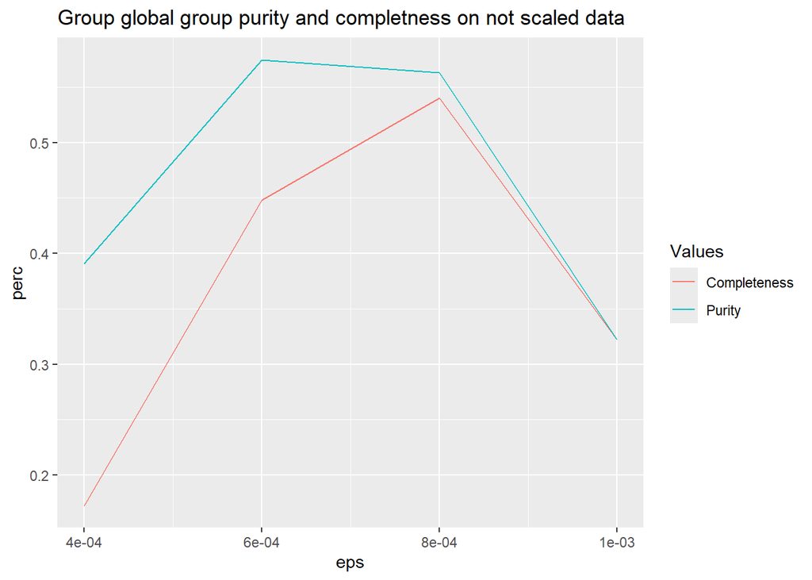

```r
plot_purity_completeness(eps_sequence_test, x_stats$pures/true_groups, x_stats$completes/true_groups, "Group global group purity and completness on not scaled data")
```

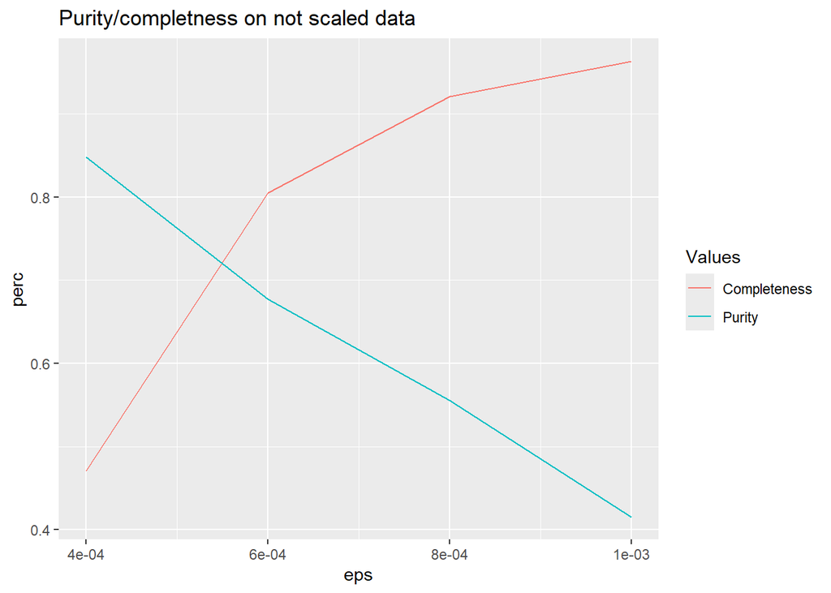

```r
plot_purity_completeness(eps_sequence_test, x_stats$purity_list, x_stats$completeness_list, "Purity/completness on not scaled data")
```

```r
points_scaled <- scale(points)
ress <- optics(points_scaled, minPts = min_members)
#optimal value obtained
blo_scans <- extractDBSCAN(ress, eps_cl = 0.025)
```

Again we can do the same for scaled data:

```r
eps_sequence_test <- seq(0.02, 0.035, 0.005)
x_stats <- extract_stats(eps_sequence_test, ress)
```

```r
pretty_print(pretty_print("Completeness", x_stats$completeness_list))
```

```
## [1] "Completeness 0.662491685798765 0.802893121939158 0.871322176762668 0.91062732252754 "
```

```r
pretty_print(pretty_print("Purity", x_stats$purity_list))
```

```
## [1] "Purity 0.857245021060811 0.738733167102937 0.645212104628135 0.572995690513728 "
```

```r
pretty_print(pretty_print("Groups", x_stats$group_list))
```

```
## [1] "Groups 40 73 110 133 "
```

```r
pretty_print(pretty_print("Clusters", x_stats$cluster_list))
```

```
## [1] "Clusters 44 75 112 134 "
```

```r
pretty_print(pretty_print("EPS", eps_sequence_test))
```

```
## [1] "EPS 0.02 0.025 0.03 0.035 "
```

```r
pretty_print(paste("True Groups", true_groups))
```

```
## [1] "True Groups 87 "
```

```r
pretty_print(pretty_print("Und. Groups", x_stats$und_gr))
```

```
## [1] "Und. Groups 53 36 31 29 "
```

```r
pretty_print(pretty_print("Complete gr.:", x_stats$completes))
```

```
## [1] "Complete gr.: 21 40 45 44 "
```

```r
pretty_print(pretty_print("Pure gr.:", x_stats$pures))
```

```
## [1] "Pure gr.: 35 51 53 49 "
```

```r
pretty_print(pretty_print("Fr:", x_stats$fr_list))
```

```
## [1] "Fr: 0.241379310344828 0.459770114942529 0.517241379310345 0.505747126436782 "
```

```r
pretty_print(pretty_print("Fp:", x_stats$fp_list))
```

```
## [1] "Fp: 0.777777777777778 0.671052631578947 0.469026548672566 0.362962962962963 "
```

```r
pretty_print(pretty_print("Spurious:", x_stats$spurious))
```

```
## [1] "Spurious: 2.29545454545455 3.24 4.41964285714286 5.82835820895522 "
```

```r
pretty_print(pretty_print("Bad class:", x_stats$bad_class))
```

```
## [1] "Bad class: 5.15909090909091 2.12 0.848214285714286 0.537313432835821 "
```

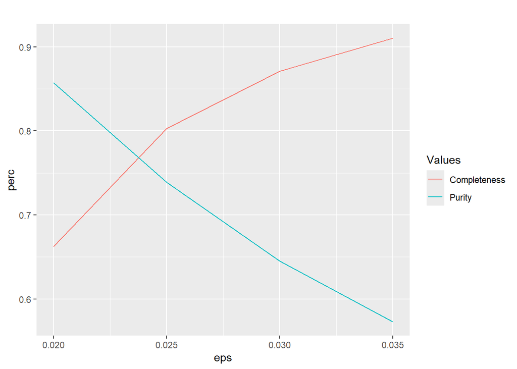

```r
plot_purity_completeness(eps_sequence_test, x_stats$purity_list, x_stats$completeness_list)
```

For global clusters:

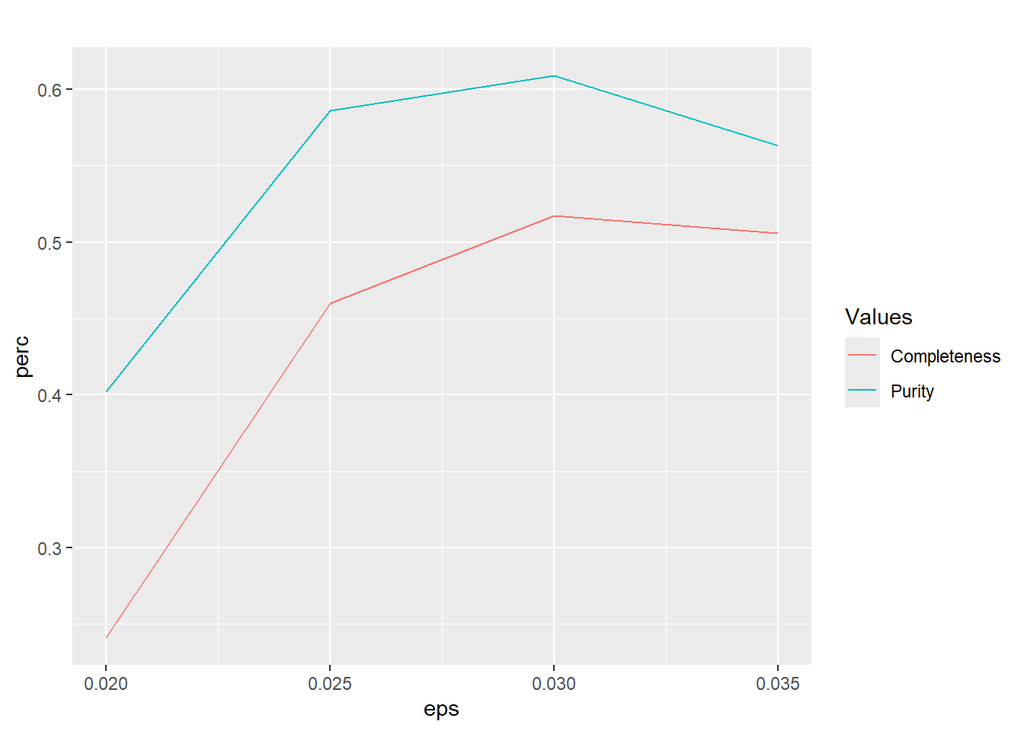

```r
plot_purity_completeness(eps_sequence_test, x_stats$pures/true_groups, x_stats$completes/true_groups)
```

## 2.1 Hyperparameter tunning

We have selected that minPts = min_members, which is a reasonable value for interpreting a group / clustering.

From the DBSCAN theory we can use the elbow on:

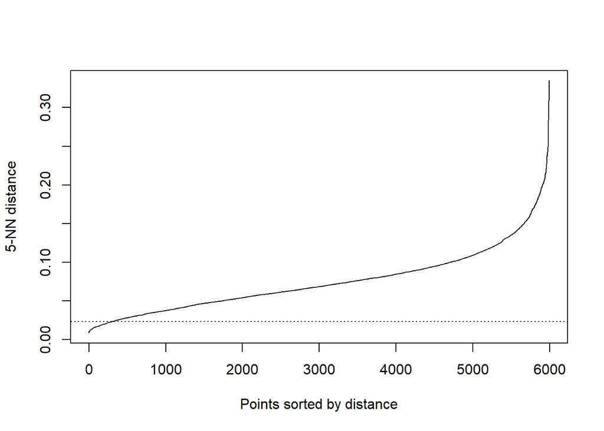

```r
kNNdistplot(x = points_scaled, k = min_members)
abline(h = 0.0235, lty = 3)
```

How reader can see, the “elbow theory” does not apply here, the reason for this is that we are not trying to optimize the clusters given by the algorithm, instead we are trying to detect groups of galaxies.

In addition are data belonging to actual clusters with more than min_members members, this reduced the space to 774 galaxies out of more than 5000.

# 3 s-Distances

Following coder allow to calculate the sdistance:

```r
#######################################
# Calculate angle between two points
#######################################
#nulos <- 0
calculate_angle <- function(v1, v2) {
    dot_product <- sum(v1 * v2)
    mod_v1 <- sqrt(sum(v1^2))
    mod_v2 <- sqrt(sum(v2^2))
    acos_angle <- dot_product / (mod_v1 * mod_v2)
    bool <- abs(acos_angle)  >1 | is.na(acos_angle)
    if(bool == TRUE) {
        0
    }else{
        acos(acos_angle)
    }

}


#######################################
# Calculate traverse distance from proper distance
#######################################
traverse_distance <- function(v1, v2, distance) {
    calculate_angle(v1, v2) * distance
}


#######################################
# Calculate scaled distance symmetric way
#######################################
d_LOS_scaled_symmetric <- function(v1, v2, redshift1, redshift2) {
    (d_LOS(v1, v2, redshift1) + d_LOS(v2, v1, redshift2)) / 2
}


#######################################
# Calculate scaled distance between two given vectors
# sfactor is global constant, f.e sfactor=0.2
#######################################
d_LOS <- function(v1, v2, redshift) {
    if(redshift< 0.01){
        sfactor <- 0.6
    } else if(redshift< 0.04){
        sfactor <- 0.5
    } else if(redshift< 0.06){
        sfactor <- 0.4
    } else if(redshift< 0.08){
        sfactor <- 0.35
    }else if(redshift< 0.1){
        sfactor <- 0.3
    }else if(redshift< 0.12){
        sfactor <- 0.19
    }else if(redshift< 0.15){
        sfactor <- 0.08
    }else if(redshift< 0.2){
        sfactor <- 0.01
    }else {
        sfactor <- 0.2
    }

    sfactor * sum((v1-v2)*v1) / sqrt(sum(v1^2))
}


#######################################
# Calculate elongated distance
# depends on sfactor (a factor, for example sfactor=0.2) and proper_distance
# v1 = c(x, y, x, distance)
# sfactor must be a global variable
#######################################
s_distance <- function(v1, v2){
    vector1 <- v1[1:3]
    vector2 <- v2[1:3]
    proper_distance <- v1[4]
    redshift1 <- v1[5]
    redshift2 <- v2[5]

    sqrt (traverse_distance(vector1, vector2, proper_distance)^2 +
              d_LOS_scaled_symmetric(vector1, vector2, redshift1, redshift2)^2
        )
}


#######################################
# Get a dist object made up from s_distances
# use a coordintates matrix as follows:
#   a<- mm[,c('x', 'y', 'z', 'dist', 'redshift')]
#   matriz_distancias <- get_matrix_of_distances(a)
# The aim is to call optics with this object as follows
#   aaa <- as.dist(matriz_distancias)
#   res <- optics(aaa, minPts = min_members)
#######################################
get_matrix_of_distances <- function(matrix_coordintates) {
    row_list <- as.list(data.frame(t(matrix_coordintates)))
    distances_matrix <- outer(row_list, row_list, FUN = Vectorize(s_distance))
    #as.dist(distances_matrix) This is not needed anymore
    distances_matrix
}
```

And then we can calculate distance matrix to apply OPTICS to this new metric, following code takes a lot of time:

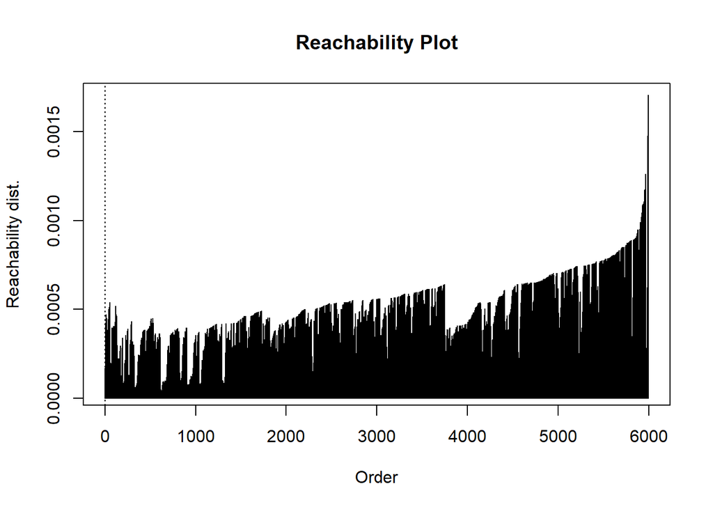

```r
a<- mm[,c('x', 'y', 'z', 'dist', 'redshift')]
distance_matrix <- get_matrix_of_distances(a)
dist_object <- as.dist(distance_matrix)
sres <- optics(dist_object, minPts = min_members)
plot(sres)
```

For the new data, we extract a DBSCAN:

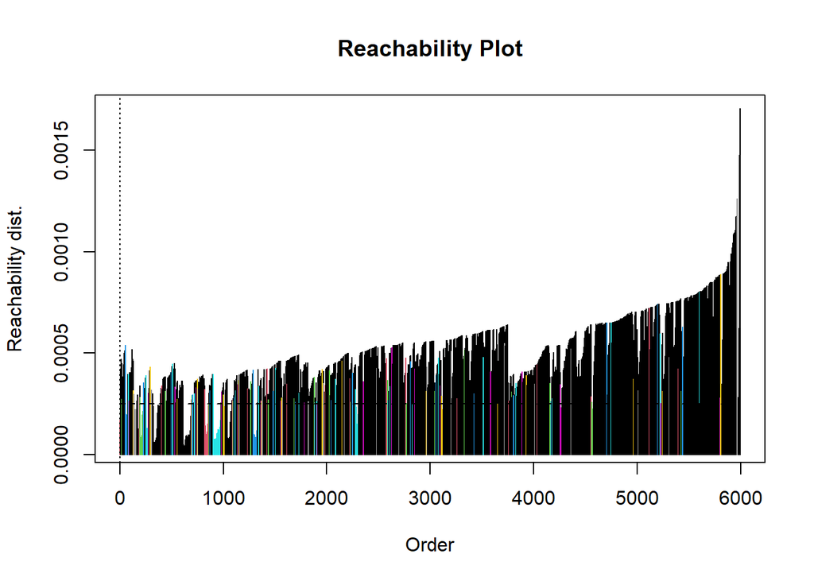

```r
sblo_scan <- extractDBSCAN(sres, eps_cl = 0.00025)
plot(sblo_scan)
```

We obtain a notable improvement:

```r
sall <- execute_stats(mm, sblo_scan)
print(paste("Mean purity", mean(sall$purity)))
```

```
## [1] "Mean purity 0.634142778392082"
```

```r
print(paste("Mean completness", mean(sall$completn)))
```

```
## [1] "Mean completness 0.963600718065004"
```

Test several hyper-parameters:

```r
#optimal value found at 0.00015
eps_sequence_test <- seq(0.00010, 0.00035, 0.00005)
x_stats <- extract_stats(eps_sequence_test, sres)
```

```r
pretty_print(pretty_print("Completeness", x_stats$completeness_list))
```

```
## [1] "Completeness 0.725153622114794 0.878828883194692 0.931361859533501 0.963600718065004 0.971105527638191 0.981053459119497 "
```

```r
pretty_print(pretty_print("Purity", x_stats$purity_list))
```

```
## [1] "Purity 0.837386714512814 0.814655602100311 0.722501829633637 0.634142778392082 0.540906898665873 0.474166803903398 "
```

```r
pretty_print(pretty_print("Groups", x_stats$group_list))
```

```
## [1] "Groups 53 96 133 167 199 212 "
```

```r
pretty_print(pretty_print("Clusters", x_stats$cluster_list))
```

```
## [1] "Clusters 55 96 134 168 199 212 "
```

```r
pretty_print(pretty_print("EPS", eps_sequence_test))
```

```
## [1] "EPS 1e-04 0.00015 2e-04 0.00025 3e-04 0.00035 "
```

```r
pretty_print(paste("True Groups", true_groups))
```

```
## [1] "True Groups 87 "
```

```r
pretty_print(pretty_print("Und. Groups", x_stats$und_gr))
```

```
## [1] "Und. Groups 44 20 15 15 18 19 "
```

```r
pretty_print(pretty_print("Complete gr.:", x_stats$completes))
```

```
## [1] "Complete gr.: 31 69 79 76 63 45 "
```

```r
pretty_print(pretty_print("Pure gr.:", x_stats$pures))
```

```
## [1] "Pure gr.: 44 76 83 80 66 49 "
```

```r
pretty_print(pretty_print("Fr:", x_stats$fr_list))
```

```
## [1] "Fr: 0.35632183908046 0.793103448275862 0.908045977011494 0.873563218390805 0.724137931034483 0.517241379310345 "
```

```r
pretty_print(pretty_print("Fp:", x_stats$fp_list))
```

```
## [1] "Fp: 0.785714285714286 0.783505154639175 0.614814814814815 0.473372781065089 0.33 0.230046948356808 "
```

```r
pretty_print(pretty_print("Spurious:", x_stats$spurious))
```

```
## [1] "Spurious: 1.90909090909091 2.14583333333333 2.76865671641791 3.64880952380952 5.14070351758794 7.34905660377358 "
```

```r
pretty_print(pretty_print("Bad class:", x_stats$bad_class))
```

```
## [1] "Bad class: 4.29090909090909 0.916666666666667 0.432835820895522 0.19047619047619 0.105527638190955 0.0660377358490566 "
```

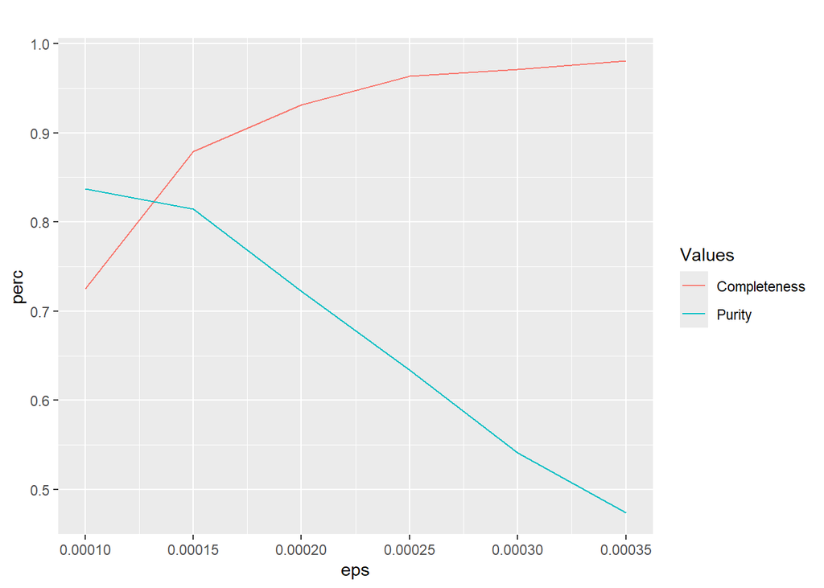

```r
plot_purity_completeness(eps_sequence_test, x_stats$purity_list, x_stats$completeness_list)
```

There is a notable improvement of te results with the sLos distances.

Finally, for groups:

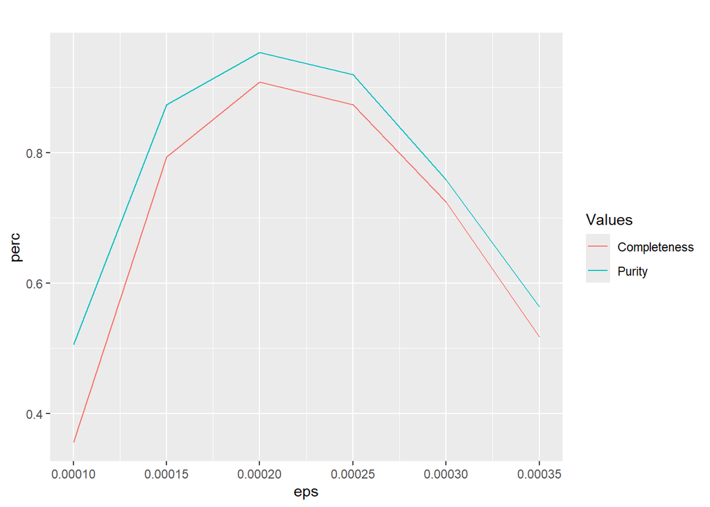

```r
plot_purity_completeness(eps_sequence_test, x_stats$pures/true_groups, x_stats$completes/true_groups)
```